# Ezekiel_ESS______New species added

Ezekiel/Julia/Derek

2023-04-17

Running Eastern Scotian Model to steady State

Load Libraries first

```r
#remotes::install_github("sizespectrum/mizerExperimental")
library(mizer)
library("assertthat")
library("optimParallel")
library("here")
library("tidyr")
library(dplyr)
#library("nloptr")
library(mizerExperimental)
library(tidyverse)
#library(mizerHowTo)
library(pbapply)
library(openair)
library(patchwork)
library(dplyr)
library(tidyr)
library(tibble)
```

Set up directories

Read in Species Parameters

```r
species_lookup <- c(
  "Gadus morhua"                   = "Atlantic Cod",
  "Melanogrammus aeglefinus"       = "Haddock",
  "Urophycis tenuis"               = "White Hake",
  "Urophycis chuss"                = "Red Hake",
  "Merluccius bilinearis"          = "Silver Hake",
  "Pollachius virens"              = "Pollock",
  "Sebastes fasciatus"             = "Redfish Unseparated",
  "Hippoglossoides platessoides"   = "American Plaice",
  "Myzopsetta ferruginea"             = "Yellowtail Flounder",  ## Limanda ferruginea
  "Glyptocephalus cynoglossus"     = "Witch Flounder",
  "Clupea harengus"                = "Atlantic Herring",
  "Mallotus villosus"              = "Capelin",
  "Amblyraja radiata"              = "Thorny Skate",
  "Leucoraja ocellata"             = "Winter Skate",
  "Squalus acanthias"              = "Spiny Dogfish",
  "Lophius americanus"             = "Monkfish",
  "Ammodytes dubius"               = "Sand Lance",
  "Myoxocephalus octodecemspinosus" = "Longhorn Sculpin",
  "Hippoglossus hippoglossus"      = "Atlantic Halibut")

species_order <- c( "Atlantic Cod", "Haddock", "White Hake", "Red Hake", "Silver Hake","Pollock",
                    "Redfish Unseparated","American Plaice", "Yellowtail Flounder","Witch Flounder",
                    "Atlantic Herring","Capelin", "Thorny Skate", "Winter Skate", "Spiny Dogfish",
                    "Monkfish", "Sand Lance", "Longhorn Sculpin", "Atlantic Halibut")

external_species_info <- read.csv("Ess_data/ESS_species_params.csv") |>
 #Hartvig et al. 2011 ; preferred (roughly) should be realised ppmr divided by 2
# I think min_ppmr_adj or min_ppmr probably best reflection of "preferred" ppmr; else could use a box predation kernel
 select(-beta) |>
  rename(beta = min_ppmr_adj) |>
  select(Species, w_max, w_mat, w_min, l_mat, beta, sigma, k_vb, a, b, age_mat) |>
  mutate(across(where(is.numeric), ~ round(., 3)),
  Species = factor(recode(Species, !!!species_lookup), levels = species_order)) |>
  filter(!is.na(Species)) |> arrange(Species) |> mutate(Species = as.character(Species)) |>
  rename(species = Species)

years_to_use<-as.character(1978:1992) #Assign years for the reference period

# #The initial Rmax was estimated from an empirical equation as in (Blanchard et al., 2014)
external_species_info <- external_species_info |> mutate(R_max = 10^11 * w_max^-1.5)
external_species_info
```

```
##                species       w_max    w_mat  w_min l_mat      beta sigma  k_vb
## 1         Atlantic Cod   82636.560 2780.285  0.001 66.49   405.922 1.260 0.163
## 2              Haddock   13539.139  376.469  0.001 35.00  1133.943 1.581 0.240
## 3           White Hake   20481.945  272.540  0.001 33.90   116.008 1.058 0.162
## 4             Red Hake    1856.869   84.634  0.001 24.45   150.021 1.396 0.190
## 5          Silver Hake    3383.218   81.113  0.001 22.90   329.277 0.895 0.384
## 6              Pollock   20408.245 1455.168  0.001 55.00   886.320 0.861 0.145
## 7  Redfish Unseparated    1752.529  153.758  0.001 21.60  3702.611 1.132 0.119
## 8      American Plaice    4741.968  137.981  0.001 26.00 10807.162 1.319 0.093
## 9  Yellowtail Flounder    2426.456  150.949  0.001 25.90  5507.941 1.562 0.111
## 10      Witch Flounder    1338.770  142.622  0.001 29.00   619.848 1.774 0.218
## 11    Atlantic Herring     732.755  122.934  0.001 25.30  9176.135 0.807 0.330
## 12             Capelin      54.489   13.670  0.001 13.00  9176.135 0.807 0.480
## 13        Thorny Skate   11718.325 2623.339  0.001 66.25   619.016 1.260 0.105
## 14        Winter Skate   29548.541 3060.460  0.001 74.50  1258.120 1.222 0.158
```

[output cut: 25 more lines]

Read in catch data/Subset and average the catch data

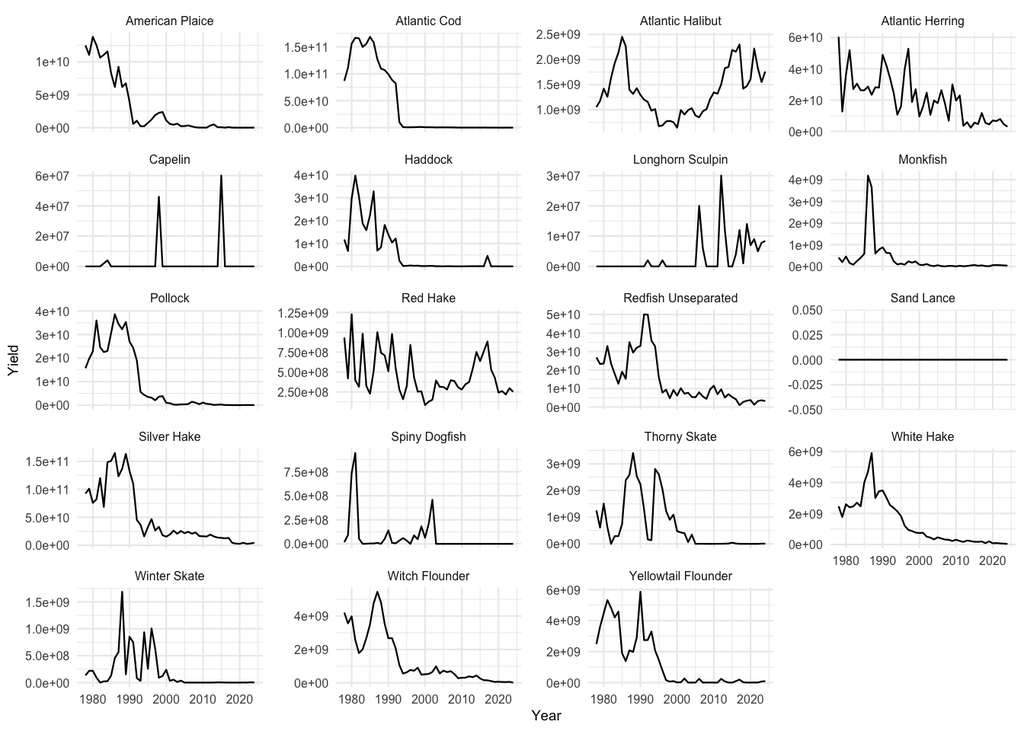

```r
catches <- readRDS("Ess_data/new_NAFO_4VW_Catches.RDS")
catches <- as.data.frame(catches)

yield_ts <- catches %>%
    filter(Year %in% 1978:2024) %>% rename(`Longhorn Sculpin` = `Sculpins (NS)`) %>%
    pivot_longer( cols = -Year, names_to = "Species",values_to = "Yield") %>%
    mutate( Yield = replace_na(Yield, 0))

## Check plot
ggplot(yield_ts, aes(x = Year, y = Yield)) + geom_line(linewidth = 0.4) +
  facet_wrap(~ Species, scales = "free_y", ncol = 4) +
  theme_minimal(base_size = 8) +
  theme(
    strip.text = element_text(size = 6),
    axis.text = element_text(size = 6),
    axis.title = element_text(size = 7),
    panel.spacing = unit(0.5, "lines") ) +
  labs(x = "Year", y = "Yield")
```

```r
#Aggregate to mean observed catch
mean_catch_nafo <- subset(yield_ts, Year <= max(years_to_use)) %>%
  group_by(Species) %>%
  summarise(yield_observed = mean(Yield, na.rm = TRUE)) %>%
  ungroup() %>% arrange(factor(Species, levels = species_order))
# set sandlance catches to NA; assume not fished (only sporadic catches)
mean_catch_nafo$yield_observed[17] <- 0 # Sand Lance
mean_catch_nafo$yield_observed[12] <- 0  # Capelin
```

```r
biomass_obs <- read.csv("Ess_data/DFO_Biomass_selected_species.csv")
biomass_obs[, -1] <- biomass_obs[, -1] * 1e3
colnames(biomass_obs) <- gsub("\\s+", " ", trimws(gsub("\\.", " ", colnames(biomass_obs))))
colnames(biomass_obs)[colnames(biomass_obs) == "YEAR"] <- "Year"
biomass_obs <- biomass_obs %>% select(Year, any_of(species_order))
biomass_obs[is.na(biomass_obs)] <- 0
```

```r
library(reshape2)
#Aggregate observed biomass to mean biomass
biomass_obs_sub <- subset(biomass_obs, Year >= 1978 & Year <= 2024)
biomass_ts <- reshape2::melt(biomass_obs_sub, id.vars = 1)
names(biomass_ts)<-c("Year","Species","Biomass")

mean_biomass_obs <- subset(biomass_ts, Year<=max(years_to_use))%>%
  group_by(Species)%>% summarise(biomass_observed =mean(Biomass,  na.rm = T))

mean_biomass_obs$biomass_observed<- ifelse(is.nan( mean_biomass_obs$biomass_observed),NA,  mean_biomass_obs$biomass_observed)
```

Introduce catch and ssb into data minimum size in survey - assume 10 but check the DFO spreadsheet

```r
#Assign obeserved biomas and catches to species
external_species_info$biomass_observed <- mean_biomass_obs$biomass_observed
external_species_info$yield_observed <- mean_catch_nafo$yield_observed
```

Set up fishing gear parameters

```r
#load gear and knife_edge_gear
fishing_type = read.csv("Ess_data/new.gear_params.csv")
fishing_type$knife_edge_size <- external_species_info$w_mat
names(fishing_type)[1] = "species"
gear_params <- fishing_type
gear_names <- gear_params$gear
```

Copy species life history parameters into the species parameters for the model

```r
external_species_info<-select(external_species_info,c("species","w_max","w_mat", "w_min","beta" ,"sigma" ,"a","b","age_mat", "biomass_observed", "yield_observed"))
# Create a Mizer multispecies parameter object using species traits and gear settings.
# - interaction = NULL: use default interaction matrix (intra = 1, inter = 0.2)
# - kappa = 1e8: sets background resource carrying capacity
# - gear_params: provides fishing gear selectivity and catchability
params <- newMultispeciesParams(external_species_info,interaction = NULL, kappa = 1e12, gear_params = gear_params)
```

```
## Because you have n != p, the default value for `h` is not very good.
## No ks column so calculating from critical feeding level.
## Using z0 = z0pre * w_max ^ z0exp for missing z0 values.
## Using f0, h, lambda, kappa and the predation kernel to calculate gamma.
```

set up initial catchability using this mean relative effort and catchability of 1 as initial value only - BUT WILL ESTIMARE LATER

```r
#assume catchability of 1, will be estimated further down

gear_params(params)$catchability <- fishing_type$catchability
gear_params(params)$yield_observed <- mean_catch_nafo$yield_observed
```

Biomass cutoff from length distributions

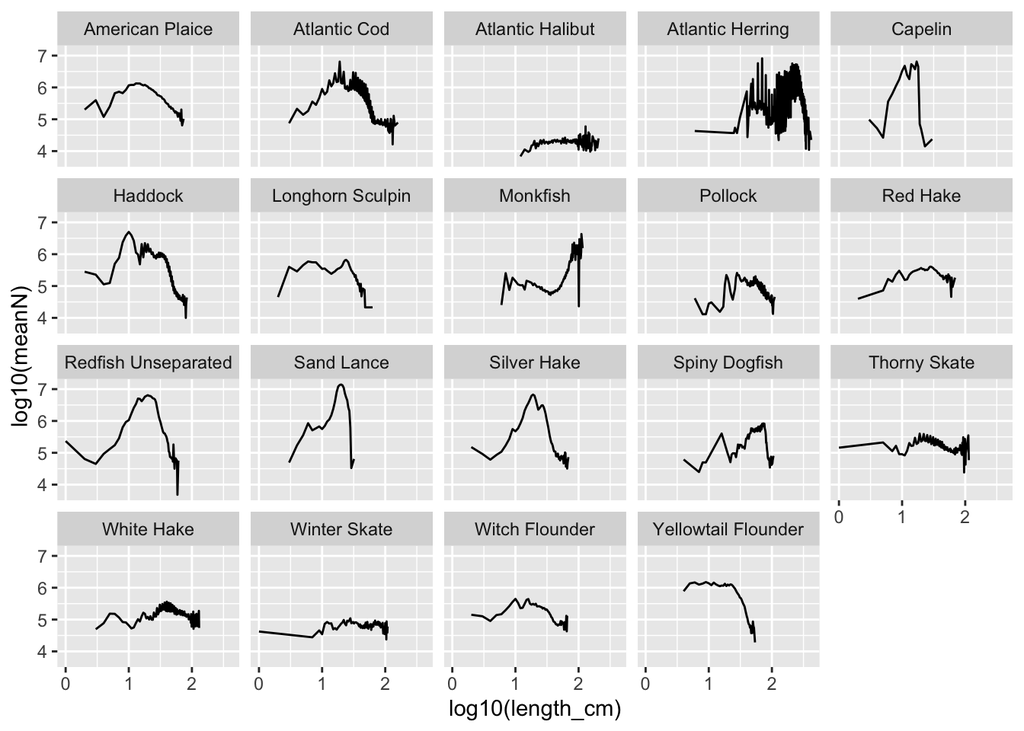

```r
stat <- read.csv("Ess_data/LF_Biomass_Abund.csv")
# ── LOOKUP: RAW SURVEY NAME -> MODEL NAME ────────────────────────────────────
species_code_lookup <- c(
  "COD(ATLANTIC)"             = "Atlantic Cod",
  "HADDOCK"                   = "Haddock",
  "WHITE HAKE"                = "White Hake",
  "SILVER HAKE"               = "Silver Hake",
  "POLLOCK"                   = "Pollock",
  "REDFISH UNSEPARATED"       = "Redfish Unseparated",
  "AMERICAN PLAICE"           = "American Plaice",
  "YELLOWTAIL FLOUNDER"       = "Yellowtail Flounder",
  "SPINY DOGFISH"             = "Spiny Dogfish",
  "HALIBUT(ATLANTIC)"         = "Atlantic Halibut",
  "SQUIRREL OR RED HAKE"      = "Red Hake",
  "MONKFISH,GOOSEFISH,ANGLER" = "Monkfish",
  "NORTHERN SAND LANCE"       = "Sand Lance",
  "WITCH FLOUNDER"            = "Witch Flounder",
  "HERRING(ATLANTIC)"         = "Atlantic Herring",
  "THORNY SKATE"              = "Thorny Skate",
  "WINTER SKATE"              = "Winter Skate",
  "LONGHORN SCULPIN"          = "Longhorn Sculpin",
  "CAPELIN"                   = "Capelin")

# ── LENGTH FREQUENCY ─────────────────────────────────────────────────────────
lengthfreq <- stat |>
  filter(YEAR >= 1978, YEAR <= 2024) |>
  select(year = YEAR, species_name_raw = COMMON_NAME, length_cm = FLEN, abundance = Abundance_Strata) |>
  mutate(species_name = species_code_lookup[species_name_raw]) |>
  filter(!is.na(species_name)) |>
  summarise(meanN = mean(abundance, na.rm = TRUE), .by = c(species_name, length_cm))

# ── PLOT ──────────────────────────────────────────────────────────────────────
p <- ggplot(lengthfreq, aes(x = log10(length_cm), y = log10(meanN), group = species_name)) +
  geom_line() + facet_wrap(~species_name)
p
```

```r
# ── BIOMASS CUTOFF ────────────────────────────────────────────────────────────
biomass_cutoff <- lengthfreq |>
  filter(meanN >= 0) |> group_by(species_name) |>
  summarise(min_l = min(length_cm), max_l = max(length_cm), .groups = "drop") |>
  left_join(external_species_info |> select(species, a, b), by = c("species_name" = "species")) |>
  mutate(min_w = round(a * min_l ^ b, 1), max_w = round(a * max_l ^ b, 1) ) |>
  select(species_name, min_l, max_l, min_w, max_w)
#external_species_info$biomass_cutoff <- biomass_cutoff$min_w
#external_species_info$biomass_cutoff$max_w <- biomass_cutoff$max_w
# ── JOIN BACK TO SPECIES INFO ─────────────────────────────────────────────────
external_species_info <- external_species_info |>
  left_join(biomass_cutoff |> select(species_name, min_w), by = c("species" = "species_name")) |>
  rename(biomass_cutoff = min_w)
# adjust max_w for some species (too small max_w from RFishBase)
ratio <-biomass_cutoff$max_w/species_params(params)$w_max
corrections<-which(ratio>1)
#
external_species_info[corrections,"w_max"]<-biomass_cutoff[which(ratio>1),"max_w"]
# #correct sandlance maturation size too
external_species_info[17,"w_mat"]<-external_species_info[17,"w_max"]*0.10
```

Copy species life history parameters into the species parameters for the model

```r
external_species_info<-select(external_species_info,c("species","w_max","w_mat", "w_min","beta" ,"sigma" ,"a","b","age_mat", "biomass_observed", "yield_observed","biomass_cutoff"))
# #reasign for spp 8 (sandlance)
external_species_info[17,"w_max"]<-154
external_species_info[17,"w_mat"]<-15

params <- newMultispeciesParams(external_species_info,interaction = NULL, resource_dynamics = "resource_semichemostat",kappa = 1e8,gear_params = gear_params)
```

```
## Because you have n != p, the default value for `h` is not very good.
## No ks column so calculating from critical feeding level.
## Using z0 = z0pre * w_max ^ z0exp for missing z0 values.
## Using f0, h, lambda, kappa and the predation kernel to calculate gamma.
```

```r
resource_params(params)$w_pp_cutoff <- 100
```

Set up fishing gear parameters

```r
#fishing_type = read.csv("Ess_data/Mat_knife_edge_gear_params2.csv")
fishing_type$knife_edge_size <- external_species_info$w_mat
names(fishing_type)[1] = "species"
gear_params <- fishing_type
gear_names <- gear_params$gear
```

Read the fishing history data/set fishing into params from NAFO set intial effort as mean_effort

```r
# Load time-varying fishing effort data (relative effort by gear or species)
effort_final <- read.csv("Ess_data/effort_by_gear.csv",row.names = 1)
fishing_history <- effort_final
years_to_use <- as.character(1978:1992)
mean_effort <- colMeans(fishing_history[years_to_use, ]) # MEan effort by gear

# Set initial fishing effort in the model to the average over the reference period
# This ensures a steady-state calibration baseline
initial_effort(params) <- unlist(mean_effort)
```

## Next action for attention

```r
# ─────────────────────────────────────────────────────────────
# SPECIES INTERACTION MATRIX
# Ecologically softened version for stable mizer dynamics
# Based on:
# - Schoener overlap guilds
# - Cook & Bundy (2010) diet composition
# - Reduced interaction intensity for numerical stability
# ─────────────────────────────────────────────────────────────
# -------------------------------------------------------------
# BASELINE
# -------------------------------------------------------------
# Weak default interaction among species
inter <- matrix(0.2,
                nrow = nrow(species_params(params)),
                ncol = nrow(species_params(params)),
                dimnames = list(species_params(params)$species,
                                species_params(params)$species))

# modest self-regulation
diag(inter) <- 0.2

# Pelagic / forage-associated species
pelagics <- c("Atlantic Herring","Capelin","Silver Hake","Red Hake","Sand Lance")

# Mid-water demersal species
mid_water <- c("White Hake","Pollock","Redfish Unseparated")

# Benthic feeders
benthivores <- c( "Haddock","American Plaice","Yellowtail Flounder","Witch Flounder","Longhorn Sculpin")

# Large piscivores
piscivores <- c("Atlantic Cod","Spiny Dogfish","White Hake","Monkfish")

# Large skates / halibut
large_elasmo <- c("Thorny Skate","Winter Skate","Atlantic Halibut")

# -------------------------------------------------------------
# WITHIN-GUILD OVERLAP
# -------------------------------------------------------------

# Moderate overlap among pelagic species
inter[pelagics, pelagics] <- 0.35

# Moderate overlap among benthic species
inter[benthivores, benthivores] <- 0.30

# Moderate overlap among piscivores
inter[piscivores, piscivores] <- 0.30

# Mid-water overlap
inter[mid_water, mid_water] <- 0.25

# -------------------------------------------------------------
# PREDATOR → PREY PREFERENCES
# rows = predator
# cols = prey
# -------------------------------------------------------------
# Piscivores strongly consume pelagic prey
inter[piscivores, pelagics] <- 0.50

# Moderate predation on mid-water fishes
inter[piscivores, mid_water] <- 0.35

# Weak-moderate predation on benthic species
inter[piscivores, benthivores] <- 0.25

# Benthivores weakly consume pelagic prey
inter[benthivores, pelagics] <- 0.10

# Mid-water predators moderately consume pelagics
inter[mid_water, pelagics] <- 0.35

# Mid-water predators weakly consume benthic prey
inter[mid_water, benthivores] <- 0.20

# -------------------------------------------------------------
# LARGE ELASMOBRANCH / HALIBUT VULNERABILITY
# -------------------------------------------------------------

# Reduced but non-zero vulnerability
inter[, large_elasmo] <- 0.15

# Large predators occasionally consume them
inter[piscivores, large_elasmo] <- 0.25

# Dogfish less effective on large skates/halibut
inter["Spiny Dogfish", large_elasmo] <- 0.10

# -------------------------------------------------------------
# SPECIES-SPECIFIC ADJUSTMENTS
# -------------------------------------------------------------

# White hake more piscivorous
inter["White Hake", benthivores] <- 0.15
inter["White Hake", "Sand Lance"] <- 0.60

# Haddock primarily benthic feeder
inter["Haddock", pelagics] <- 0.15
inter["Haddock", piscivores] <- 0.05

# Atlantic Halibut mainly demersal ambush predator
inter["Atlantic Halibut", pelagics] <- 0.15
inter["Atlantic Halibut", benthivores] <- 0.50

# Thorny skate deeper offshore than winter skate
inter["Thorny Skate", "Winter Skate"] <- 0.10
inter["Winter Skate", "Thorny Skate"] <- 0.10

# -------------------------------------------------------------
# STABILITY ADJUSTMENTS
# -------------------------------------------------------------

# Reduce vulnerability of slow-growing species
inter[, "Spiny Dogfish"] <- 0.02
inter[, "American Plaice"] <- inter[, "American Plaice"] * 0.60
inter[, "Redfish Unseparated"] <- inter[, "Redfish Unseparated"] * 0.50

# Weak cannibalism for dogfish
inter["Spiny Dogfish", "Spiny Dogfish"] <- 0.05

# Reduce predation pressure on redfish
inter["Atlantic Cod", "Redfish Unseparated"] <- 0.10
inter["White Hake", "Redfish Unseparated"] <- 0.10
inter["Monkfish", "Redfish Unseparated"] <- 0.10


# -------------------------------------------------------------
# FINAL ASSIGNMENT
# ------------------------------------------------------------

params <- setInteraction(params, inter)
```

## Predator–prey interaction matrix

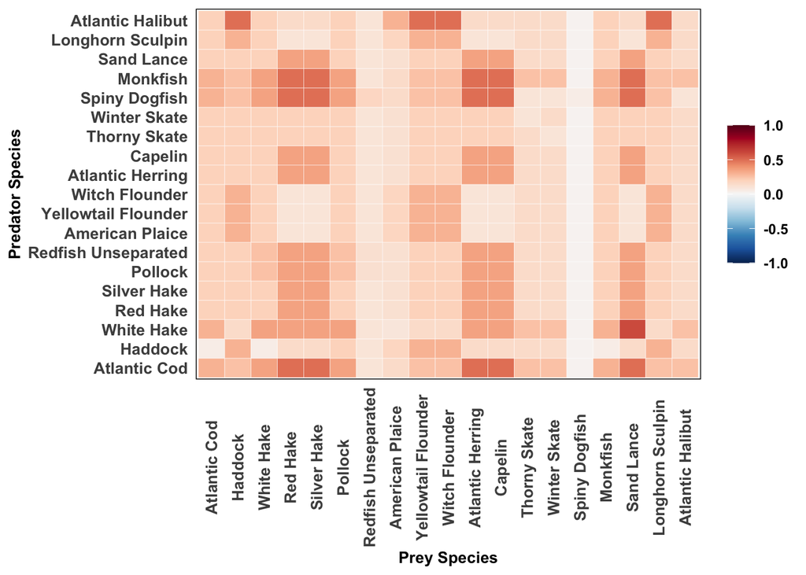

```r
library(RColorBrewer)

# Species names
species <- c(
  "Atlantic Cod", "Haddock", "White Hake", "Red Hake", "Silver Hake","Pollock",
  "Redfish Unseparated", "American Plaice", "Yellowtail Flounder",
  "Witch Flounder", "Atlantic Herring", "Capelin", "Thorny Skate","Winter Skate",
  "Spiny Dogfish", "Monkfish", "Sand Lance","Longhorn Sculpin", "Atlantic Halibut")

n <- length(species)

# Initialize matrix
inter <- matrix(0.2, nrow = n, ncol = n,
                dimnames = list(species, species))
diag(inter) <- 0.2

# Guild definitions
pelagics     <- c("Atlantic Herring", "Capelin", "Silver Hake", "Red Hake", "Sand Lance")
mid_water    <- c("White Hake", "Pollock", "Redfish Unseparated")
benthivores  <- c("Haddock", "American Plaice", "Yellowtail Flounder", "Witch Flounder", "Longhorn Sculpin")
piscivores   <- c("Atlantic Cod", "Spiny Dogfish", "White Hake", "Monkfish")
large_elasmo <- c("Thorny Skate", "Winter Skate", "Atlantic Halibut")

# Within-guild overlap
inter[pelagics, pelagics]       <- 0.35
inter[benthivores, benthivores] <- 0.30
inter[piscivores, piscivores]   <- 0.30
inter[mid_water, mid_water]     <- 0.25

# Predator-prey
inter[piscivores, pelagics]    <- 0.50
inter[piscivores, mid_water]   <- 0.35
inter[piscivores, benthivores] <- 0.25
inter[benthivores, pelagics]   <- 0.10
inter[mid_water, pelagics]     <- 0.35
inter[mid_water, benthivores]  <- 0.20

# Large elasmobranchs
inter[, large_elasmo]                <- 0.15
inter[piscivores, large_elasmo]      <- 0.25
inter["Spiny Dogfish", large_elasmo] <- 0.10

# Species-specific
inter["White Hake", benthivores]       <- 0.15
inter["White Hake", "Sand Lance"]      <- 0.60
inter["Haddock", pelagics]             <- 0.15
inter["Haddock", piscivores]           <- 0.05
inter["Atlantic Halibut", pelagics]    <- 0.15
inter["Atlantic Halibut", benthivores] <- 0.50
inter["Thorny Skate", "Winter Skate"]  <- 0.10
inter["Winter Skate", "Thorny Skate"]  <- 0.10

# Stability adjustments
inter[, "Spiny Dogfish"]                     <- 0.02
inter[, "American Plaice"]                   <- inter[, "American Plaice"] * 0.60
inter[, "Redfish Unseparated"]               <- inter[, "Redfish Unseparated"] * 0.50
inter["Spiny Dogfish", "Spiny Dogfish"]      <- 0.05
inter["Atlantic Cod", "Redfish Unseparated"] <- 0.10
inter["White Hake", "Redfish Unseparated"]   <- 0.10
inter["Monkfish", "Redfish Unseparated"]     <- 0.10

# Melt to long format
inter_long <- reshape2::melt(inter,
                   varnames   = c("Predator", "Prey"),
                   value.name = "InteractionStrength")

# Diverging palette, red = high, blue = low
pal <- rev(brewer.pal(11, "RdBu"))

# Plot
heatmap_plot <- ggplot(inter_long,
                       aes(x = Prey, y = Predator, fill = InteractionStrength)) +
  geom_tile(color = "white", linewidth = 0.1) +
  scale_fill_gradientn(
    colors = pal,
    limits = c(-1, 1),
    breaks = c(-1, -0.5, 0, 0.5, 1)) +
  labs(x = "Prey Species", y = "Predator Species") +
  theme_minimal(base_family = "Arial") +
  theme(
    axis.text.x      = element_text(angle = 90, hjust = 0.5, vjust = 0.5,
                                    size = 10, face = "bold"),
    axis.text.y      = element_text(size = 10, face = "bold"),
    axis.title       = element_text(size = 10, face = "bold"),
    legend.title     = element_blank(),
    legend.text      = element_text(size = 9, face = "bold"),
    panel.grid       = element_blank(),
    panel.border     = element_rect(color = "black", fill = NA, linewidth = 0.5),
    panel.background = element_blank()
  )

print(heatmap_plot)
```

Run params to steady state

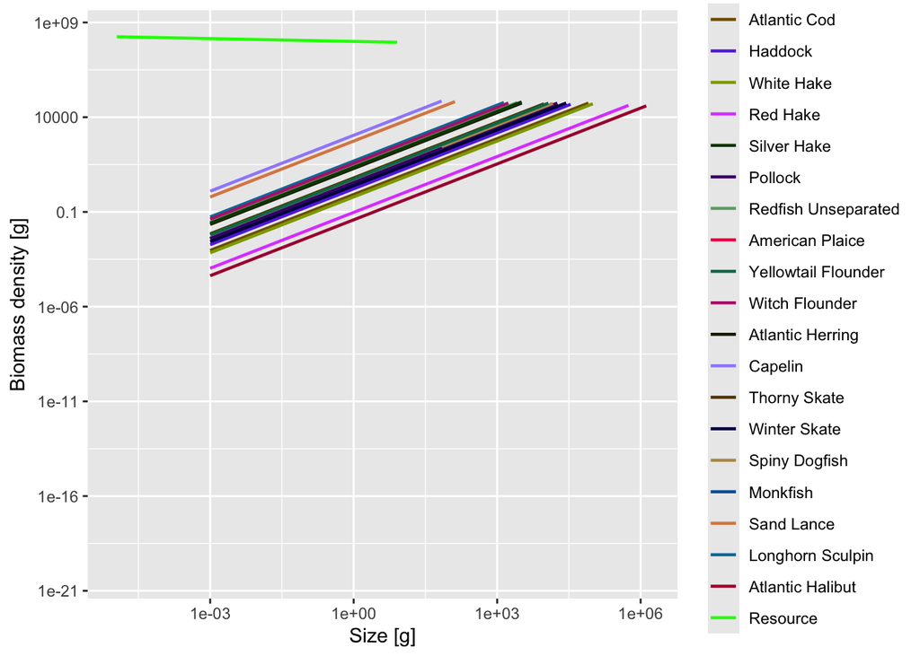

```r
# Plot initial model spectra (before running steady state)
# `power = 2` rescales biomass densities to approximate weight-based biomass (biomass ~ N * w^2)
plotSpectra(params, power = 2)
```

```r
# Run the model to steady state: iterates until no major change in biomass over time
params <- steady(params)
```

```
## Simulation run did not converge after 99 years. Value returned by the distance function was: 0.065026095102434
```

```r
# Plot resulting spectra using Plotly (interactive)
# Useful to check for unrealistic kinks or mismatches in species/resource structure
plotlySpectra(params, power = 2)
```

[interactive chart not shown]

Inspect plots via: tuneParams(params) check size spectra of resource and community line up, growth curves look reasonably similar to von Bertalanffy, diets look reasonable, etc.

Calibrate the scale

```r
#plotBiomassVsSpecies(params)
# run below x 2
params <- calibrateBiomass(params)
params<-steady(params)
```

```
## Simulation run did not converge after 99 years. Value returned by the distance function was: 0.0128997768213063
```

```r
# check Sheldon spectrum and feeding level to ensure enough food available
plotlySpectra(params,power= 2)
```

[interactive chart not shown]

```r
plotlyFeedingLevel(params)
```

[interactive chart not shown]

Rescale Species Spectra, Rince and repeat (till convergence is achieved in 1.5 years)

```r
# Iteratively improve the calibration by adjusting model parameters
# to better match observed biomasses, and then re-solving for steady state
for (i in 1:20) {
  params <- params |>
    matchBiomasses() |>  # Adjust species parameters to better match observed biomasses
    steady()             # Recalculate the steady-state solution
}
```

```
## Simulation run did not converge after 99 years. Value returned by the distance function was: 0.0596168453546972
```

```
## Simulation run did not converge after 99 years. Value returned by the distance function was: 0.0162550480672608
```

```
## Convergence was achieved in 70.5 years.
```

```
## Convergence was achieved in 48 years.
```

```
## Convergence was achieved in 45 years.
```

```
## Convergence was achieved in 40.5 years.
```

```
## Convergence was achieved in 36 years.
```

```
## Convergence was achieved in 31.5 years.
```

```
## Convergence was achieved in 27 years.
```

```
## Convergence was achieved in 21 years.
```

```
## Convergence was achieved in 16.5 years.
```

```
## Convergence was achieved in 7.5 years.
```

```
## Convergence was achieved in 9 years.
```

```
## Convergence was achieved in 7.5 years.
```

```
## Convergence was achieved in 4.5 years.
```

```
## Convergence was achieved in 1.5 years.
## Convergence was achieved in 1.5 years.
## Convergence was achieved in 1.5 years.
## Convergence was achieved in 1.5 years.
## Convergence was achieved in 1.5 years.
```

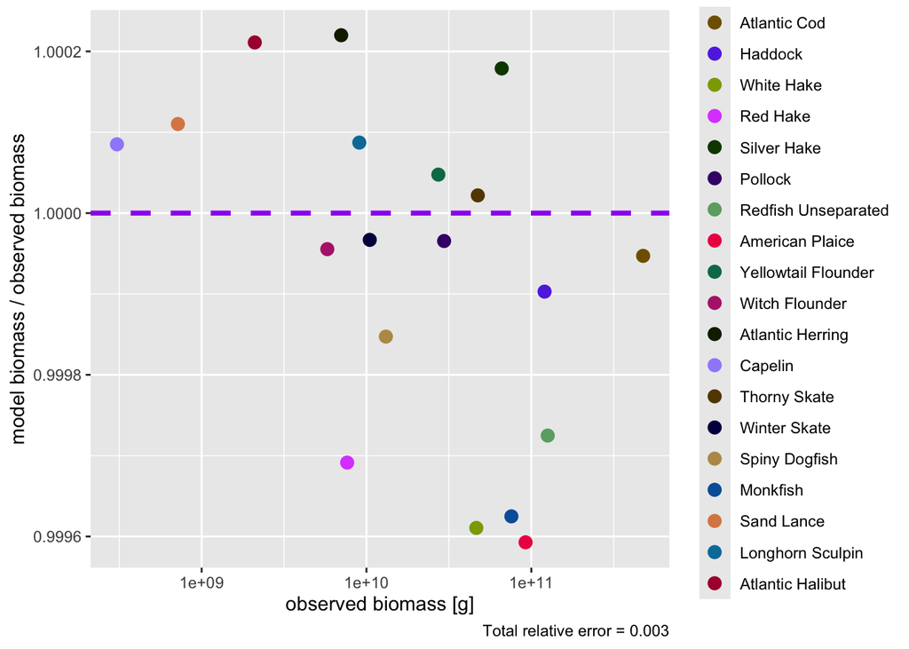

```r
# Plot comparison of model-predicted vs observed biomass
# - ratio = TRUE: plots the ratio (model / observed), ideal value is 1
# - labels = FALSE: do not display species names on the plot
plotBiomassObservedVsModel(params, ratio = TRUE, labels = FALSE)
```

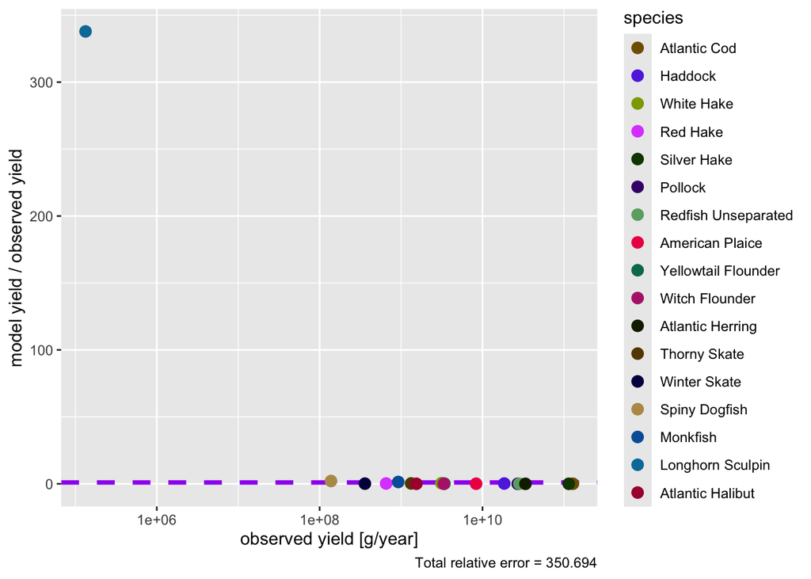

```r
# Plot comparison of model-predicted vs observed yield (catch)
# - ratio = TRUE: shows how well the model predicts catch relative to observed data
# - labels = FALSE: cleaner plot without species labels
plotYieldObservedVsModel(params, ratio = TRUE, labels = FALSE)
```

```r
# Plot interactive feeding level by size for each species
# Shows how close species are to satiation (values near 1 = full, <0.2 = hungry)
# Useful to check realism of trophic dynamics and possible starvation
plotlyFeedingLevel(params)
```

[interactive chart not shown]

View Spectra

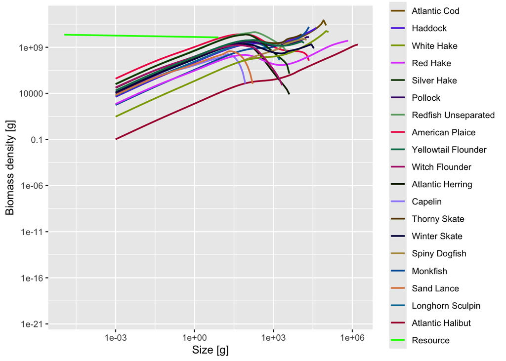

```r
# Plot the model spectra (biomass across size classes for all species and resource)
# - power = 2: scales the abundance spectrum to biomass (N(w) * w^2)
# Useful to assess size structure and whether any species dominate unrealistically
plotSpectra(params, power = 2)
```

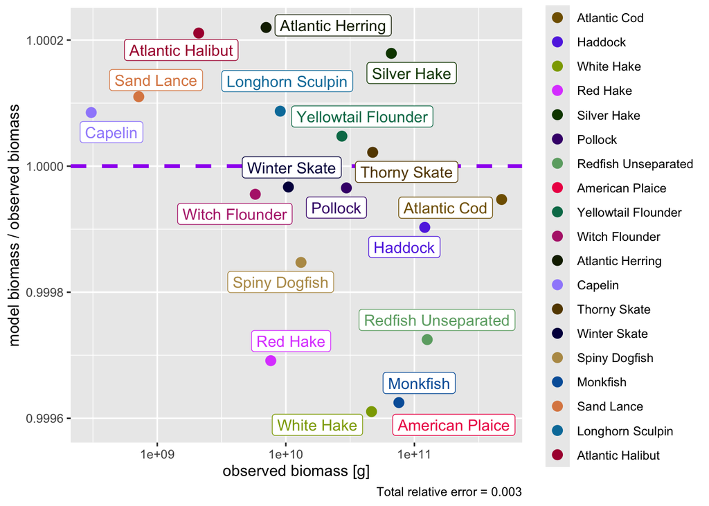

```r
# Plot model-predicted vs observed biomass (log-log scale by default)
# - ratio = FALSE (default): shows raw predicted vs observed biomass for each species
# Ideal results lie close to the 1:1 diagonal line
plotBiomassObservedVsModel(params)
```

# Set Sensitivity to Fishing

Check how model responses to fishing - resilience to fishing is influenced by the reproduction paramters being estimated by the steps above…. -Check ratio between modelled and obs catches, rescale catchability -Adjust catchability, then setady state again

```r
# gear_params(params)$yield_observed <- mean_catch_nafo$yield_observed
# # # get ratio of obs vs modelled yields, note sandlances are omitted so need to add in the vector with a 1 for sandlance
# d <- plotYieldObservedVsModel(params, return_data = TRUE)$ratio
# ratio <- c(d[1:11],1,d[12:15],1,d[16:17])
#
# # rerun match biomass, growth, & steady, but this time also estimating catchabilities, using matchYield, needed to produce the species reported yields
# # repeat below until minimising years to converge
#
# for ( i in 1:19){
# params<- params|> matchBiomasses()|> matchYield()|> steady()
# }
#
# plotYieldObservedVsModel(params, ratio = T)
# plotBiomassObservedVsModel(params, ratio = T)
#

#check approx fishing mort not unrealistically large or small
#
catchability = c(
  0.15,  # Atlantic Cod          – important demersal prey
  0.10,  # Haddock               – moderate demersal prey
  0.08,  # White Hake            – moderate prey
  0.08,  # Red Hake              – moderate prey
  0.10,  # Silver Hake           – moderate prey
  0.10,  # Pollock               – moderate prey
  0.08,  # Redfish Unseparated   – moderate prey
  0.15,  # American Plaice       – benthic, less accessible
  0.05,  # Yellowtail Flounder   – benthic, less accessible
  0.05,  # Witch Flounder        – benthic, less accessible
  0.45,  # Atlantic Herring      – major pelagic prey
  0.45,  # Capelin               – major pelagic prey
  0.05,  # Thorny Skate          – spiny, less preferred
  0.45,  # Winter Skate          – benthic, less preferred
  0.05,  # Spiny Dogfish         – spines, less preferred
  0.05,  # Monkfish              – large benthic, less accessible
  0.30,  # Sand Lance            – abundant schooling prey
  0.05,  # Longhorn Sculpin      – benthic, less accessible
  0.03   # Atlantic Halibut      – very large, rare prey
)
gear_params(params)$catchability <-catchability
# ### adjust catcahbility for silver hake
# gear_params(params)$catchability[9]<- 0.05
# # adjust catcahbility for dogfish
# gear_params(params)$catchability[13]<-0.05
# # adjust catcahbility for white hake
# gear_params(params)$catchability[11]<-0.2
# # catchability (and yields) too low for witch flounder
# gear_params(params)$catchability[12]<-1
# gear_params(params)$catchability[13]<-0.05


# adjust knfe edge size selectivity for silver hake
# gear_params(params)$knife_edge_size[9]<-0.9*species_params(params)$w_mat[9]
# # adjust knfe edge size for dogfish
# gear_params(params)$knife_edge_size[10]<-1.2*species_params(params)$w_mat[10]
# # adjust knife edge size for yellowtail
# gear_params(params)$knife_edge_size[13]<-1.2*species_params(params)$w_mat[13]

# check converges in 1.5 years

for(i in 1:19){
# try to match to catch instead of biomass for problem species
params<-matchYields(params, species=c(1:19))
params<-matchBiomasses(params,species=c())
params<-steady(params)
}
```

```
## The following species have no yield observations and their abundances will not be changed: Capelin, Sand Lance.
```

```
## Convergence was achieved in 63 years.
## The following species have no yield observations and their abundances will not be changed: Capelin, Sand Lance.
```

```
## Convergence was achieved in 49.5 years.
## The following species have no yield observations and their abundances will not be changed: Capelin, Sand Lance.
```

```
## Convergence was achieved in 48 years.
## The following species have no yield observations and their abundances will not be changed: Capelin, Sand Lance.
```

```
## Convergence was achieved in 39 years.
## The following species have no yield observations and their abundances will not be changed: Capelin, Sand Lance.
```

```
## Convergence was achieved in 37.5 years.
## The following species have no yield observations and their abundances will not be changed: Capelin, Sand Lance.
```

```
## Convergence was achieved in 33 years.
## The following species have no yield observations and their abundances will not be changed: Capelin, Sand Lance.
```

```
## Convergence was achieved in 28.5 years.
## The following species have no yield observations and their abundances will not be changed: Capelin, Sand Lance.
```

```
## Convergence was achieved in 28.5 years.
```

```
## The following species have no yield observations and their abundances will not be changed: Capelin, Sand Lance.
```

```
## Convergence was achieved in 24 years.
## The following species have no yield observations and their abundances will not be changed: Capelin, Sand Lance.
```

```
## Convergence was achieved in 18 years.
## The following species have no yield observations and their abundances will not be changed: Capelin, Sand Lance.
```

```
## Convergence was achieved in 18 years.
```

```
## The following species have no yield observations and their abundances will not be changed: Capelin, Sand Lance.
```

```
## Convergence was achieved in 15 years.
```

```
## The following species have no yield observations and their abundances will not be changed: Capelin, Sand Lance.
```

```
## Convergence was achieved in 1.5 years.
## The following species have no yield observations and their abundances will not be changed: Capelin, Sand Lance.
```

```
## Convergence was achieved in 1.5 years.
```

```
## The following species have no yield observations and their abundances will not be changed: Capelin, Sand Lance.
```

```
## Convergence was achieved in 1.5 years.
## The following species have no yield observations and their abundances will not be changed: Capelin, Sand Lance.
```

```
## Convergence was achieved in 1.5 years.
```

```
## The following species have no yield observations and their abundances will not be changed: Capelin, Sand Lance.
```

```
## Convergence was achieved in 1.5 years.
## The following species have no yield observations and their abundances will not be changed: Capelin, Sand Lance.
```

```
## Convergence was achieved in 1.5 years.
```

```
## The following species have no yield observations and their abundances will not be changed: Capelin, Sand Lance.
```

```
## Convergence was achieved in 1.5 years.
```

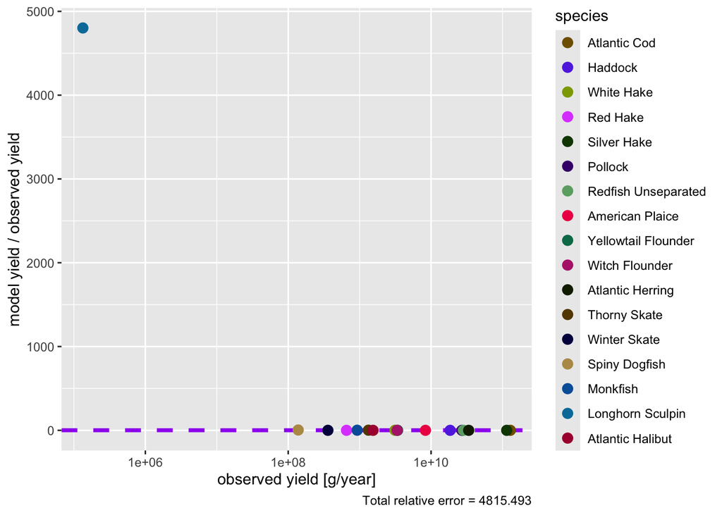

```r
# # check calibration plots again
plotYieldObservedVsModel(params, ratio = T,labels = F)
```

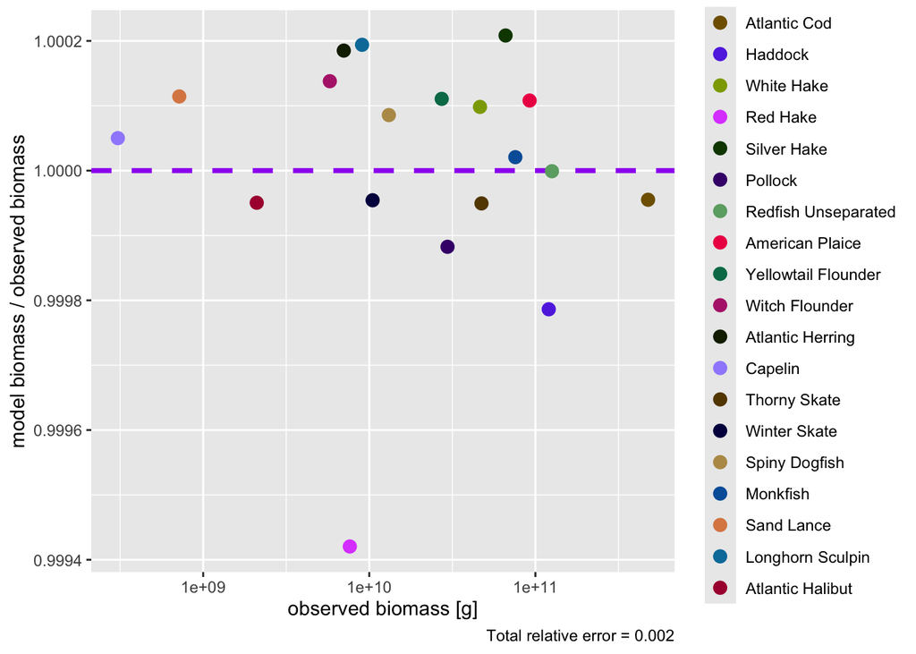

```r
plotBiomassObservedVsModel(params,labels = F)
```

- need to check Fvsyield curves(and other plots)

If needed, tuned reproduction_level to produce desire Fmsy for each species (viewed per species)

```r
   # rep_tuned <- rep(0.5,19)
   rep_tuned[8:12] <- 0.3 # witch flounder yellow flounder american place and capelin
   rep_tuned[17] <- 0.3 # Sandlance
   params <- setBevertonHolt(params, reproduction_level = rep_tuned)
   params <- steady(params)
```

```
## Convergence was achieved in 1.5 years.
```

```r
   #
   # #check cod
   # plotYieldVsF(params,species = 18)
   # getYieldVsF(params,species = 18)
```

Check YieldvsF plots for each species, ensuring dome shaped and ideally a peak yield roughly around expected single-species Fmsy

```r
# # # # Loop through and then scroll though all  plots
#      specs<-unique(species_params(params)$species)
#      plots <- list()
#      for (i in 1:length(specs)) {plots[[i]]<-plotYieldVsF(params,species = i,F_range = seq(0.01,0.8,0.01))}

# # # # # # # ## you can then manually go through each plot, e.g. change the number in [[]] below (or save them)
# #     # Arrange plots in a  grid
#    library(gridExtra)
#    grid.arrange(plots[[1]],
#                 plots[[2]],
#                 plots[[3]],
#                 plots[[4]],
#                 plots[[5]],
#                 plots[[6]],
#                 plots[[7]],
#                 plots[[8]],
#                 plots[[9]],
#                 plots[[10]],
#                 plots[[11]],
#                 plots[[12]],
#                 plots[[13]], nrow = 5, ncol = 3)
```

## Diagnostics: Now check steady state, again

```r
# Run the model to steady state and return the full simulation object
# - return_sim = TRUE: keeps the time series data (vs. just returning final params)
# - t_max = 100: allows up to 100 time steps to reach convergence
sim <- steady(params, return_sim = TRUE, t_max = 100)
```

```
## Convergence was achieved in 1.5 years.
```

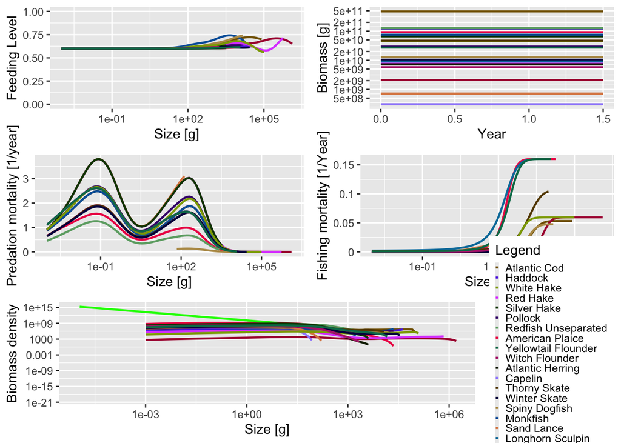

```r
# Quick plot of total biomass and yields over time (main summary)
plot(sim)
```

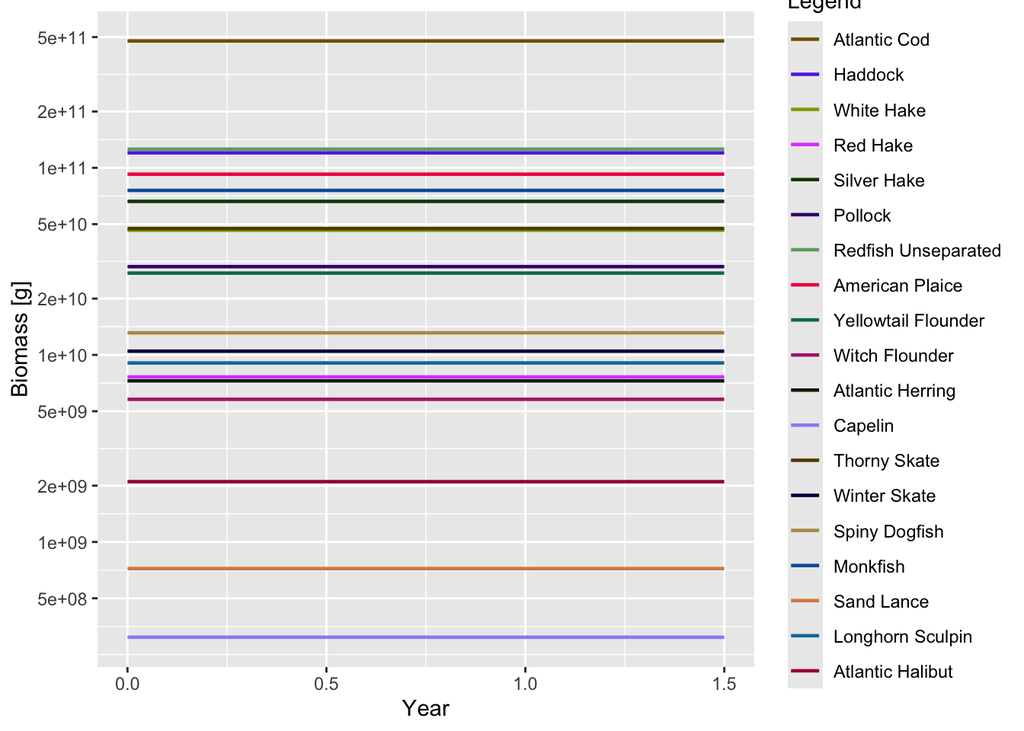

```r
# Check Diagnostic plots
# Plot species biomass over time
# Useful to check if species stabilize or fluctuate at steady state
plotBiomass(sim)
```

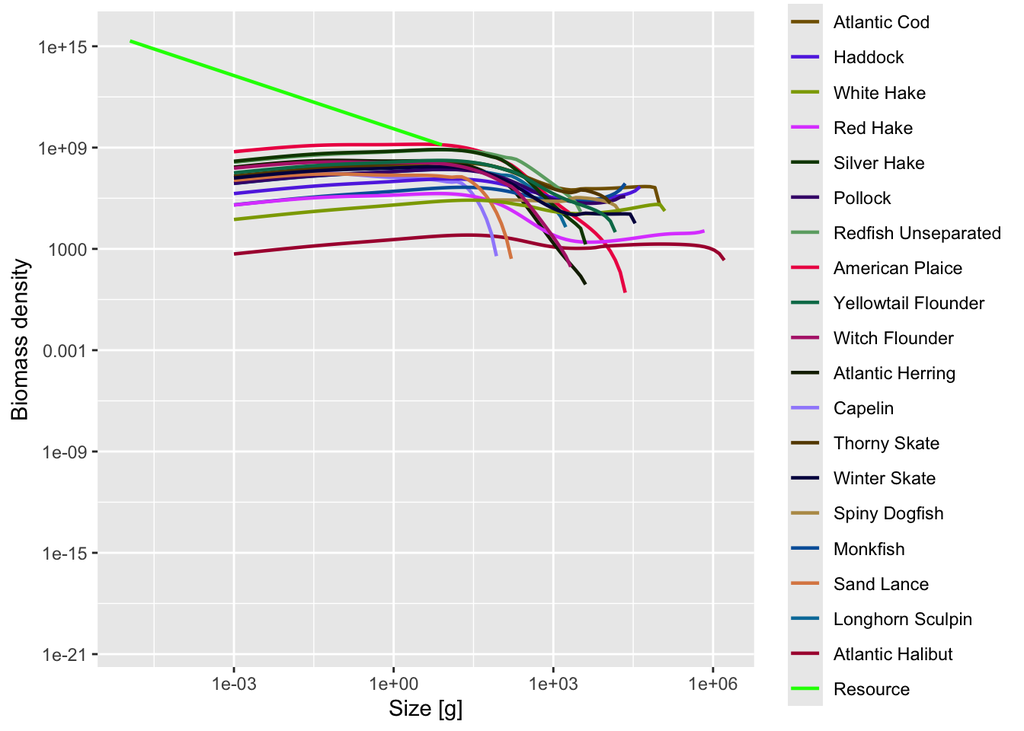

```r
# Plot spectra (biomass by size) from the final state
# Reveals trophic structure and size-based energy flow
plotSpectra(sim)
```

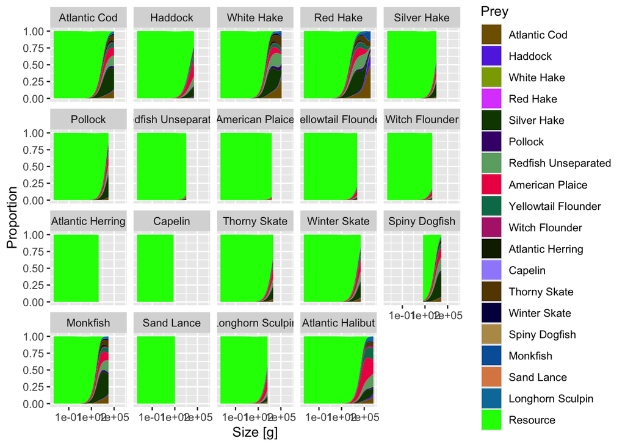

```r
# Plot species diet composition by size
# Shows who eats whom across size classes
plotDiet(params)
```

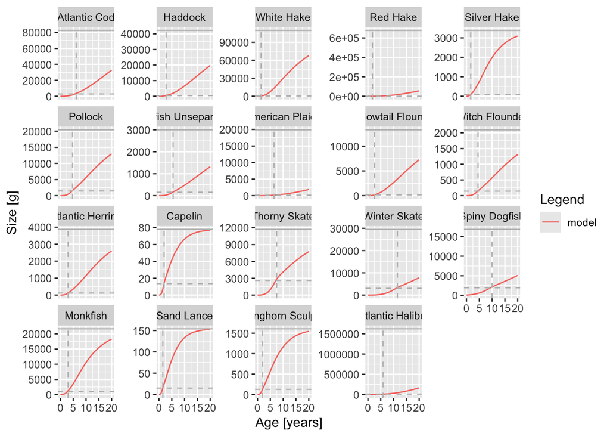

```r
# Plot growth curves for each species
# - species_panel = TRUE: shows separate panels per species
# - max_age = 20: restricts plots to ages up to 20
plotGrowthCurves(params, species_panel = TRUE, max_age = 20)
```

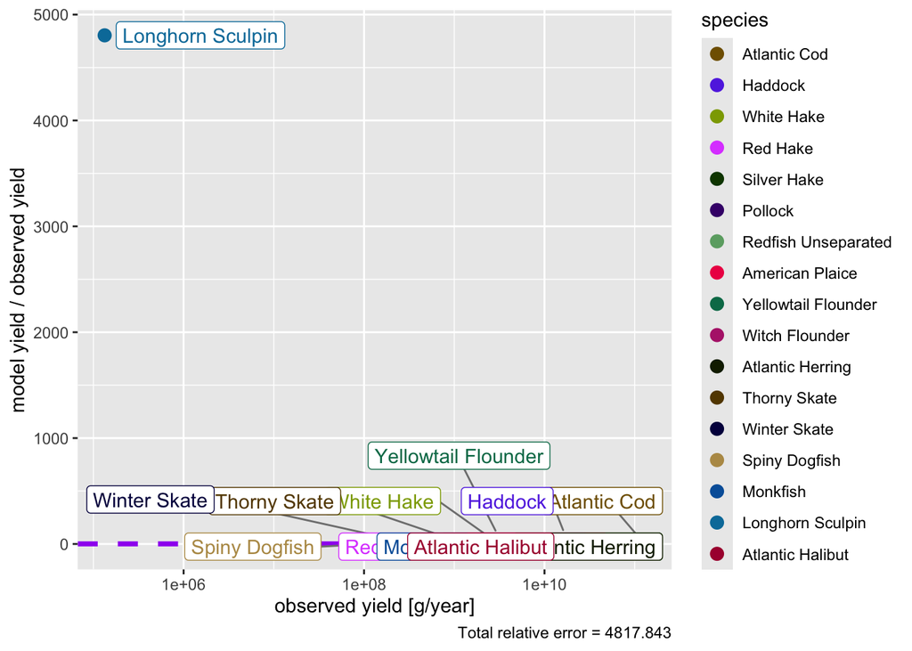

```r
# Compare model vs observed yield (catch)
# - ratio = TRUE: visualizes model/observed ratio; ideal = 1
plotYieldObservedVsModel(params, ratio = TRUE)
```

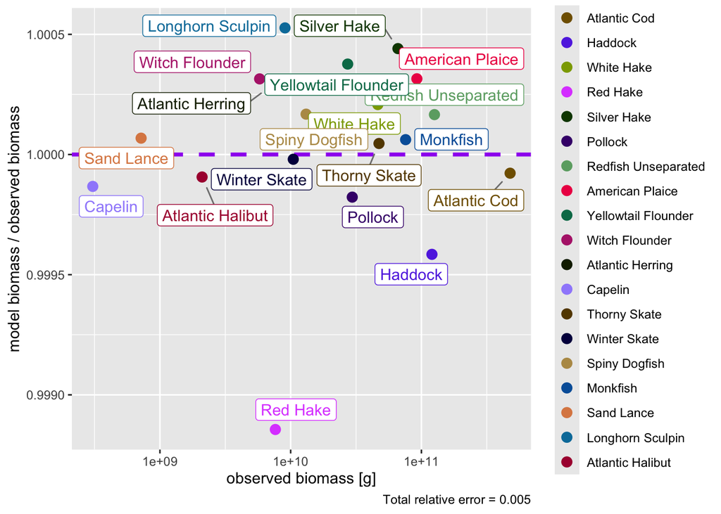

```r
# Compare model vs observed biomass
# - ratio = TRUE: visualizes model/observed ratio; ideal = 1
plotBiomassObservedVsModel(params, ratio = TRUE)
```

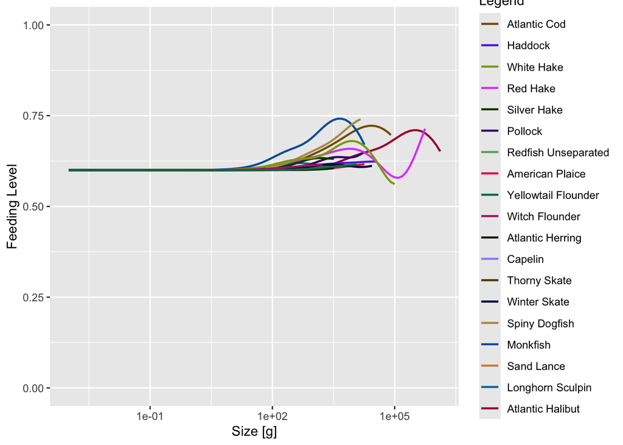

```r
# Plot feeding level by size
# Reveals how full each species is at each size (0 = starving, 1 = satiated)
plotFeedingLevel(params)
```

# Examining Growth curves for supplements

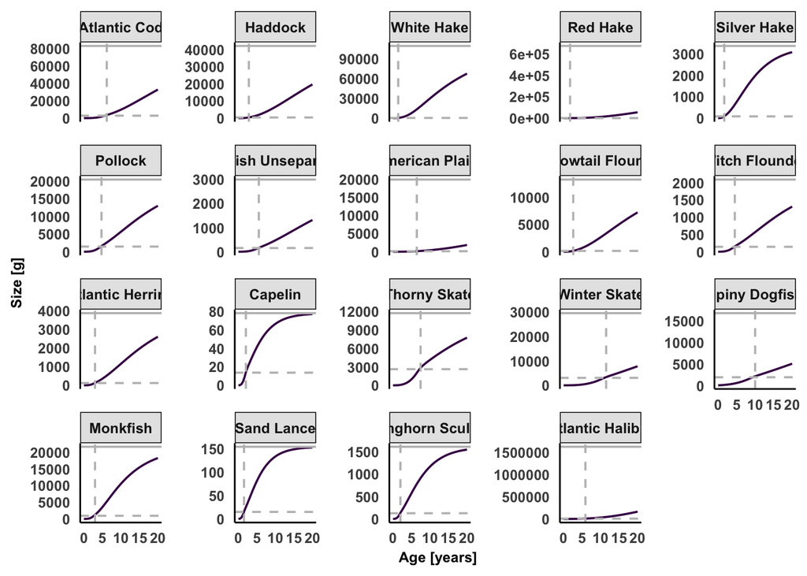

```r
GrowthCurves <- plotGrowthCurves(params, species_panel = TRUE, max_age = 20) +
  theme_minimal(base_size = 14) +
  scale_color_viridis_d() +
  labs(
    x = "Age (Years)",
    y = "Size (g)") +
  theme(
    panel.grid       = element_blank(),
    panel.spacing    = unit(1, "lines"),
    strip.text       = element_text(size = 9, face = "bold"),
    strip.background = element_rect(fill = "grey90", color = "black", linewidth = 0.5),
    axis.text        = element_text(size = 9, face = "bold"),
    axis.title       = element_text(size = 9, face = "bold"),
    axis.line        = element_line(color = "black", linewidth = 0.5),
    legend.position  = "none"
  ) +
  facet_wrap(~Species, scales = "free_y")

GrowthCurves
```

```r
ggsave(filename = paste0(save_dir, "GrowthCurves.jpeg"), plot = GrowthCurves,
       width = 11, height = 8.5, units = "in",dpi = 400)
```

Check diet proportions of each species in predator diets, can compare with Table 4.1.1.1 in Cook & Bundy 2010 DFO report

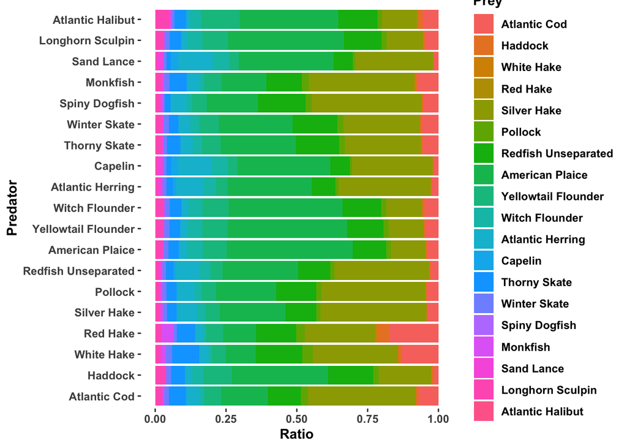

```r
#Calculate proportion of each species in each species diet across pred and prey  sizes
#diet <- data.frame(reshape2::melt(d4))
diet<-data.frame(melt(apply(getDiet(params)[,which(params@w>10),1:19], c(1,3),sum)/rowSums(apply(getDiet(params)[,which(params@w>10),1:19], c(1,3),sum)[,])))

predator<-levels(diet $predator)<- c("Atlantic Cod","Haddock", "White Hake", "Red Hake", "Silver Hake", "Pollock","Redfish Unseparated","American Plaice", "Yellowtail Flounder","Witch Flounder","Atlantic Herring","Capelin","Thorny Skate","Winter Skate","Spiny Dogfish", "Monkfish","Sand Lance", "Longhorn Sculpin","Atlantic Halibut")
diet <- diet %>%
  rename(Prey= prey, Predator= predator, Ratio = value )
diet_interaction <- ggplot(diet, aes(fill = Prey, x = Predator, y = Ratio)) +
  geom_bar(position = "stack", stat = "identity") +
  coord_flip() +
  theme(
    panel.background = element_blank(),  # Remove background behind the plot
    plot.background = element_blank(),   # Remove background for the entire plot
    axis.title.x = element_text(face = "bold", size = 11),  # Bolden x-axis title
    axis.title.y = element_text(face = "bold", size = 11),
    axis.text.x = element_text(face = "bold", size = 9),
    axis.text.y = element_text(face = "bold", size = 9),
    legend.text = element_text(face = "bold", size =9), # Bolden y-axis title
    legend.title = element_text(face = "bold", size = 11) #
  ) +
  labs(x = "Predator", y = "Ratio")  # Ensure axis labels are explicitly set
ggsave(filename = paste0(save_dir, "diet_interaction.jpeg"), plot = diet_interaction,
       width = 11, height = 8.5, units = "in",dpi = 400)
diet_interaction
```

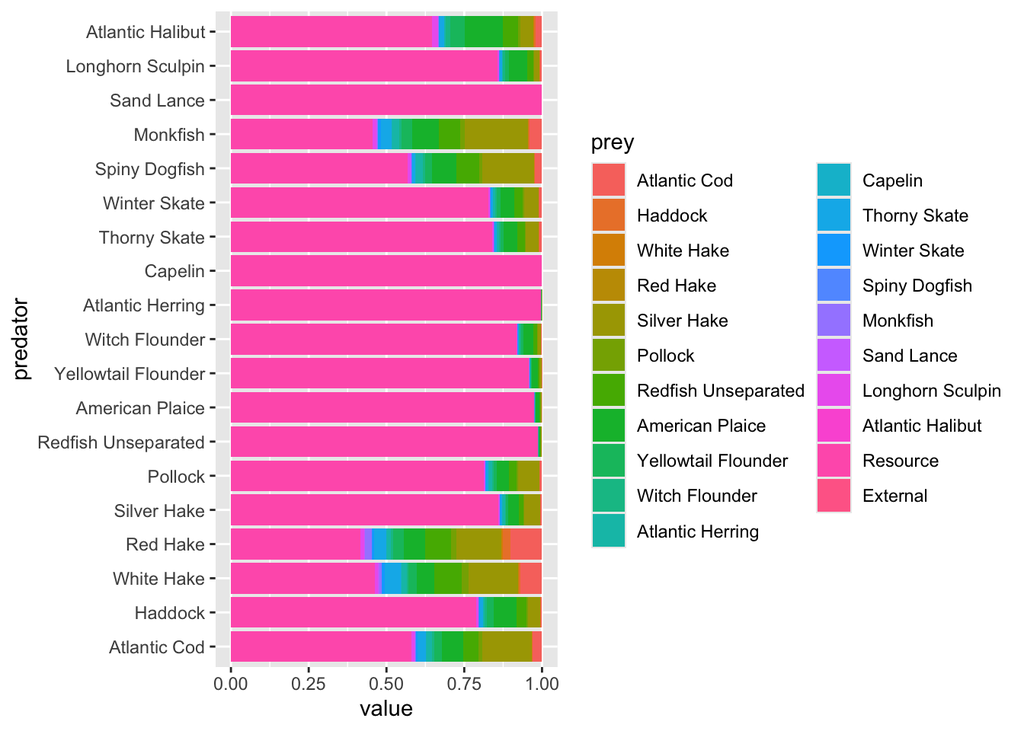

```r
# with resource
diet <- data.frame(melt(apply(getDiet(params)[,which(params@w>10),], c(1,3),sum)/rowSums(apply(getDiet(params)[,which(params@w>10),], c(1,3),sum)[,])))

ggplot(diet,aes(fill = prey, x = predator, y = value)) +
    geom_bar(position = "stack", stat = "identity") + coord_flip()
```

Create size spectrum plots by species with size distribution data from DFO RV Trawl Surveys (q-corrected)

```r
stat <- read.csv("Ess_data/LF_Biomass_Abund.csv")
# ------------------------------------------------------------
# 1. Load and reshape biomass-at-length to long format
# ------------------------------------------------------------
bio_size <- stat |>
  filter(YEAR >= 1978, YEAR <= 2024) |>
  select(Year = YEAR, species_name_raw = COMMON_NAME, length_cm = FLEN, Biomass = Biomass_Strata_KG) |>
  mutate(Species = species_code_lookup[species_name_raw]) |>
  filter(!is.na(Species)) |>
  select(Year, Species, length_cm, Biomass)

# ------------------------------------------------------------
# 2. Check observed length range per species
# ------------------------------------------------------------
max_min_size <- bio_size |>
  group_by(Species) |> summarise(min_l = min(length_cm), max_l = max(length_cm))
print(max_min_size)
```

```
## # A tibble: 19 × 3
##    Species             min_l max_l
##    <chr>               <dbl> <dbl>
##  1 American Plaice         2    74
##  2 Atlantic Cod            3   159
##  3 Atlantic Halibut       12   207
##  4 Atlantic Herring        6   420
##  5 Capelin                 3    30
##  6 Haddock                 2    83
##  7 Longhorn Sculpin        2    63
##  8 Monkfish                6   116
##  9 Pollock                 6   111
## 10 Red Hake                2    69
## 11 Redfish Unseparated     1    61
## 12 Sand Lance              3    32
## 13 Silver Hake             2    69
## 14 Spiny Dogfish           4   106
## 15 Thorny Skate            1   114
## 16 White Hake              3   130
## 17 Winter Skate            1   109
## 18 Witch Flounder          2    66
## 19 Yellowtail Flounder     4    54
```

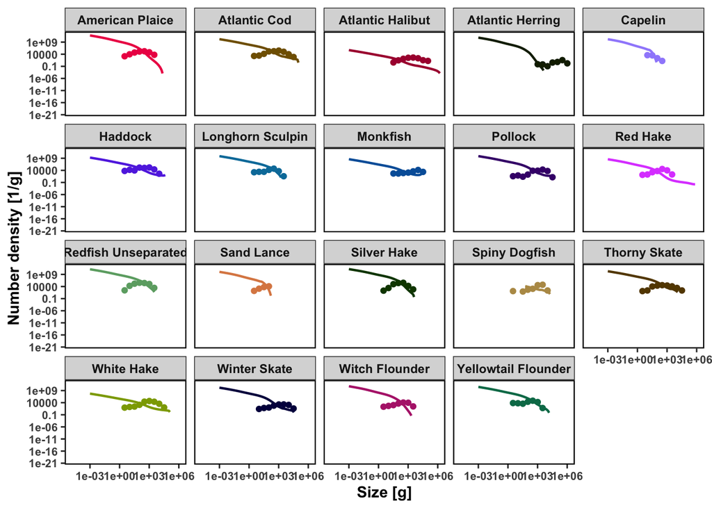

```r
# ------------------------------------------------------------
# 3. Join L-W parameters and compute weight
# ------------------------------------------------------------
wl <- data.frame(
  Species = species_params(params)$species,
  a       = species_params(params)$a,
  b       = species_params(params)$b)

bio_size <- bio_size |>
  left_join(wl, by = "Species") |>
  mutate(w = a * length_cm ^ b) |>
  filter(!is.na(Biomass), Year < 1992)

# ------------------------------------------------------------
# 4. Bin into weight classes and normalise biomass
# ------------------------------------------------------------
breaks <- 10 ^ seq(0, 6, 0.5)
upp    <- 10 ^ seq(0.5, 6,   0.5)
low    <- 10 ^ seq(0,   5.5, 0.5)
widths <- upp - low
mid    <- (widths + 2 * widths) / 2

bio_size <- bio_size |> mutate( weightclass  = cut(w, breaks = breaks),
    norm_biomass = Biomass / widths[as.integer(cut(w, breaks = breaks))])

levels(bio_size$weightclass) <- mid
bio_size$weightclass <- round(as.numeric(as.character(bio_size$weightclass)), 2)

# ------------------------------------------------------------
# 5. Summarise: normalised biomass per weight class x year x species
# ------------------------------------------------------------
biomass_size_spectra <- bio_size |>
  group_by(weightclass, Year, Species) |>
  summarise(nbiomass = sum(norm_biomass), .groups = "drop")

mean_biomass_size_spectra <- biomass_size_spectra |>
  group_by(weightclass, Species) |>
  summarise(mean_nbiomass = mean(nbiomass), .groups = "drop")

# ------------------------------------------------------------
# 6. Plot: mizer spectra + observed biomass size spectra
# ------------------------------------------------------------
size_distributions <- plotSpectra(params, power = 0, resource = FALSE) +
  geom_point(
    data = mean_biomass_size_spectra,
    aes(x = weightclass, y = mean_nbiomass, colour = Species)) +
  facet_wrap(~Species) +
  labs(x = "Weight Class (g)", y = "Normalised Mean Biomass") +
  theme_bw() +
  theme(
    legend.position = "none",
    axis.title.x    = element_text(face = "bold"),
    axis.title.y    = element_text(face = "bold"),
    strip.text      = element_text(face = "bold"),
    axis.text.x     = element_text(size = 8, face = "bold"),
    axis.text.y     = element_text(size = 8, face = "bold"),
    panel.grid      = element_blank(),
    panel.border    = element_rect(color = "black", linewidth = 0.8)
  )
size_distributions
```